# 140.651 - Lab 10

## HW4 Problem 7

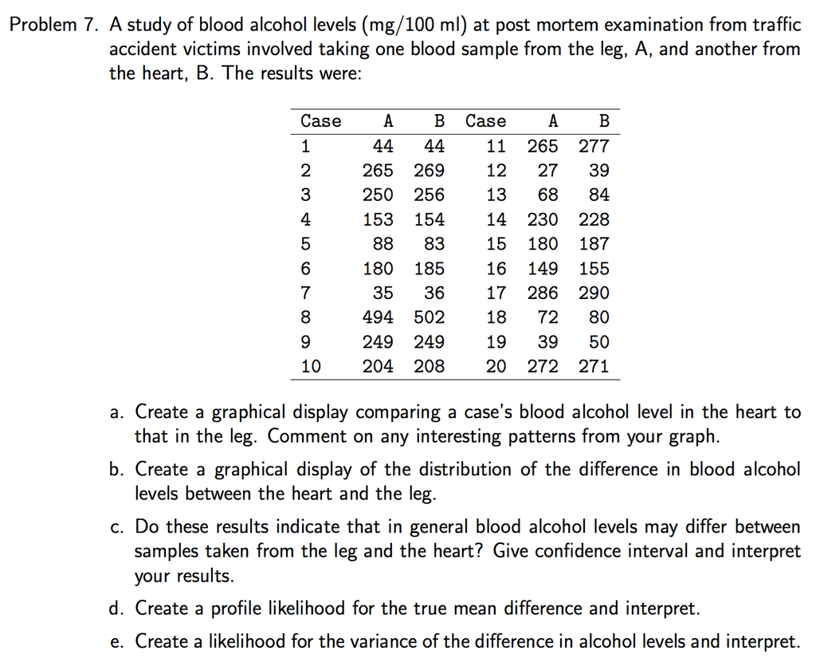

### a. Create a graphical display comparing a case’s blood alcohol level in the heart to that in the leg. Comment on any interesting patterns from your graph.

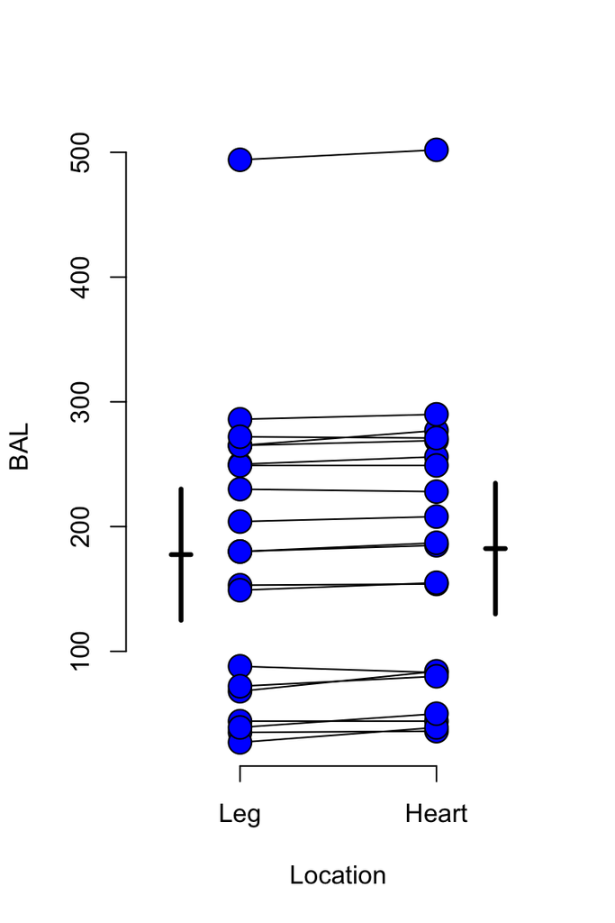

```r
## Data
A <- c( 44,265,250,153, 88,180, 35,494,249,204,
       265, 27, 68,230,180,149,286, 72, 39,272)
B <- c( 44,269,256,154, 83,185, 36,502,249,208,
       277, 39, 84,228,187,155,290, 80, 50,271)
plot(c(.5, 2.5), range(A, B), type = "n",
     axes = FALSE, xlab = "Location", ylab = "BAL")
axis(1, c("Leg", "Heart"), at = 1 : 2)
axis(2)
## Horizontal lines representing mean values in both groups
lines(c(.65, .75), rep(mean(A), 2), lwd = 3)
lines(c(2.25, 2.35), rep(mean(B), 2), lwd = 3)
## Vertical lines representing mean +/- 2 * standard deviation of the mean
lines(c(.70, .70), mean(A) + c(-1, 1) * 2 * sd(A) / sqrt(length(A)),
      lwd = 3)
lines(c(2.30, 2.30), mean(B) + c(-1, 1) * 2 * sd(B) / sqrt(length(B)),
      lwd = 3)
for (i in 1 : 20){
   lines(1 : 2, c(A[i], B[i]), lwd = 1)
   points(1 : 2, c(A[i], B[i]), pch = 21, bg = "blue", cex = 2)
}
```

The blood alcohol level appears to be slightly higher in the heart than in the leg. One person had a very high blood alcohol level.

### b. Create a graphical display of the distribution of the difference in blood alcohol levels between the heart and the leg.

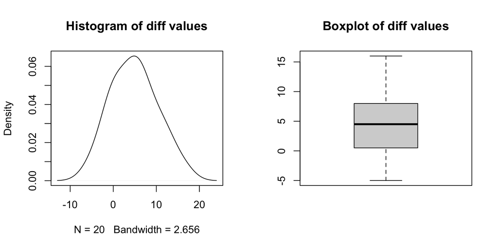

```r
diff <- B - A
par(mfrow=c(1,2))

## Try a histogram
plot(density(diff), main = "Histogram of diff values")

## Try a boxplot
boxplot(diff, main = "Boxplot of diff values")
```

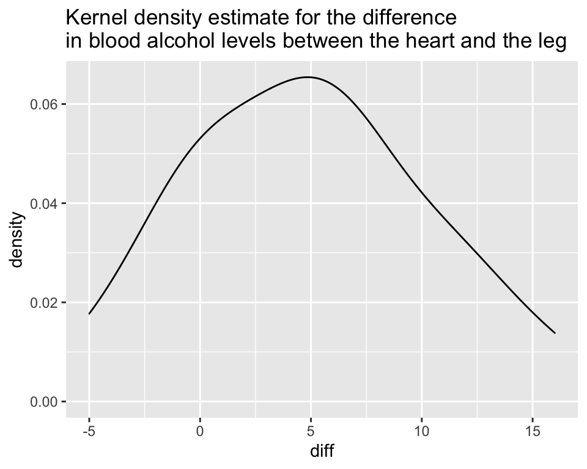

```r
library(ggplot2)
ggplot(data.frame(diff), aes(x = diff)) +
  geom_density(stat = "density") +
  labs(title = "Kernel density estimate for the difference\nin blood alcohol levels between the heart and the leg")
```

### c. Do these results indicate that in general blood alcohol levels may differ between samples taken from the leg and the heart? Give confidence interval and interpret your results.

Recall relevant Lecture slides:

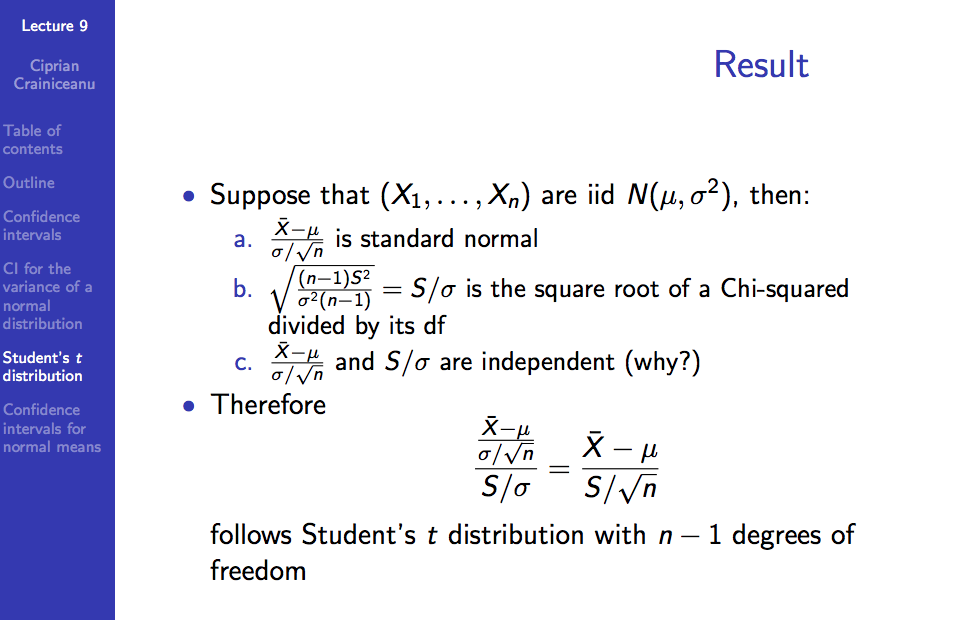

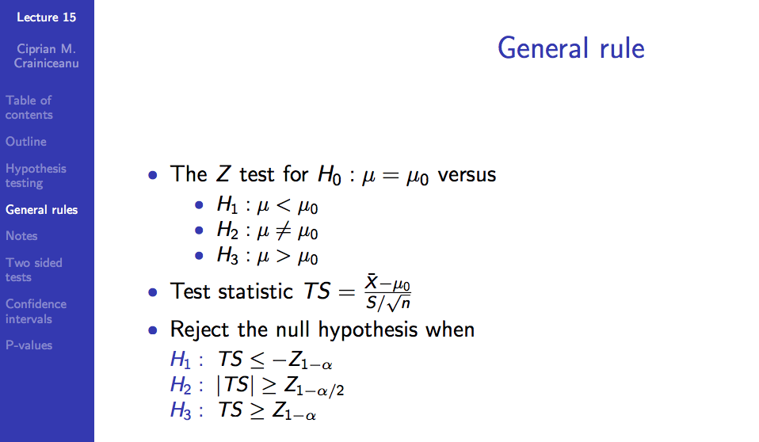

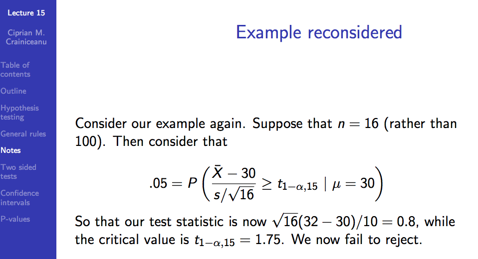

#### Approach: Hypothesis testing

Here we have:

- The two-sided $t$-test

$$\begin{aligned}
H_0: & \mu = \mu_0 \overset{here}{=} 0 \\
H_2: & \mu \neq \mu_0
\end{aligned}$$

- Test statistics is of the form

$$TS = \frac{\overline{X}_n - \mu_0}{S/\sqrt{n}} \sim \text{ Student's } t\text{-distribution with }n − 1 \text{ degrees of freedom}$$

- Denote $t$ to be the actual *observed value of the test statistic* $TS$ that we see in our data. Hypothesis testing procedure tells us to reject $H_0$ at significance level $\alpha$ when $|t| \geq t_{1 - \alpha/2; \; \text{df} = n-1}$.

```r
mu0 <- 0
n <- length(diff)
t_val <- (mean(diff) - mu0) / (sd(diff) / sqrt(n))

## Does it holds that: $|ts| >= t_{1-alpha/2 ; df=n-1} for alpha=0.05?
abs(t_val) >= qt(.975, df = n - 1)
```

```
## [1] TRUE
```

- Conclusion: at significance level $\alpha=0.05$, we reject the null hypothesis that the difference between samples taken from the leg and the heart is $0$.
- Otherwise (if above result was FALSE), we would conclude: at significance level $\alpha=0.05$, we fail to reject the null hypothesis that the difference between samples taken from the leg and the heart is $0$. (We would rather **not** say: we accept $H_0$).

#### Corresponding p-value

- Recall: p-value of a test is the probability of seeing a result *at least as extreme as* the one that we actually observe, assuming the null hypothesis is true.
- Our result can be summarized as $t$, that is, value of test statistic $TS$ that we have actually observed. In our data: $\overline{X}_n = 4.85$, $s = 5.373$, $n = 20$, $\mu_0 = 0$ and hence

$$t = \frac{4.85 - 0}{5.373179006/\sqrt{20}} = 4.036690264$$

- The above result is then compared to a random variable $TS$ whose distribution is $t$-distribution with $20−1$ degrees of freedom to calculate a p-value. The probability that the result is *at least as extreme as the one we observe* is then

$$\begin{aligned}
P(TS \geq |t|) + P(TS \leq -|t|) & = P(TS \geq 4.036690264) + P(TS \leq -4.036690264) \\
&
\end{aligned}$$

```r
t_val <- (mean(diff) - mu0) / (sd(diff) / sqrt(n))
pt(t_val, df = 19, lower.tail = FALSE) + pt(-t_val, df = 19, lower.tail = TRUE)
```

```
## [1] 0.0007045972
```

- Conclusion: Obtained p-value $0.0007045971618$ is less than the assumed significance level $\alpha=0.05$; we therefore reject the null hypothesis that the difference between samples taken from the leg and the heart is $0$.
- Otherwise (if above result was FALSE), we would conclude: Obtained p-value $k$ is larger than the assumed significance level $\alpha=0.05$, we therefore fail to reject the null hypothesis that the difference between samples taken from the leg and the heart is $0$. (We would rather **not** say: we accept $H_0$).

#### Approach: Confidence Interval construction

From the lecture: **Don’t just report P-values, give CIs too!**.

- Assuming the test statistic $TS = \frac { \overline { X } - \mu } { s / \sqrt { n } }$ follows Student’s $t$-distribution with $n-1$ degreed of freedom, we can write:

$$\begin{aligned}
\alpha & = P \left( \left| \frac { \overline { X } - \mu } { s / \sqrt { n } } \right| > t _ { 1 - \alpha / 2; \; \text{df}=n-1 } \; \right) \\
1 - \alpha & = P \left( \left| \frac { \overline { X } - \mu } { s / \sqrt { n } } \right| \leq t _ { 1 - \alpha / 2; \; \text{df}=n-1 } \; \right) \\
1 - \alpha & = P \left( - t _ { 1 - \alpha / 2; \; \text{df}=n-1 } \; \leq \frac { \overline { X } - \mu } { s / \sqrt { n } } \leq t _ { 1 - \alpha / 2; \; \text{df}=n-1 } \; \right) \\
1 - \alpha & = P \left( - t _ { 1 - \alpha / 2; \; \text{df}=n-1 } \cdot \frac{s}{\sqrt{n}} - \overline { X } \; \leq - \mu \leq t _ { 1 - \alpha / 2; \; \text{df}=n-1 } \cdot \frac{s}{\sqrt{n}} - \overline { X } \; \right) \\
1 - \alpha & = P \left( t _ { 1 - \alpha / 2; \; \text{df}=n-1 } \cdot \frac{s}{\sqrt{n}} + \overline { X } \; \geq \mu \geq - t _ { 1 - \alpha / 2; \; \text{df}=n-1 } \cdot \frac{s}{\sqrt{n}} + \overline { X } \; \right)\\
1 - \alpha & = P \left( \overline { X } - t _ { 1 - \alpha / 2; \; \text{df}=n-1 } \cdot \frac{s}{\sqrt{n}} \; \leq \mu \leq \overline { X } + t _ { 1 - \alpha / 2; \; \text{df}=n-1 } \cdot \frac{s}{\sqrt{n}} \; \right)
\end{aligned}$$

- Hence for the observed data, the $95$% confidence interval for parameter $\mu$ is $[2.335274817, 7.364725183]$.

```r
n <- length(diff)
mean(diff) + c(-1, 1) * qt(.975, df = n - 1) * sd(diff) / sqrt(n)
```

```
## [1] 2.335275 7.364725
```

- Conclusion: $95$% confidence interval for parameter $\mu$ is $[2.34, 7.36]$, suggesting evidence that the blood alcohol measurements are different (the interval does not contain $0$). Specifically, the heart measurements appear to be higher.

#### All above, but with built-in method in `R`

```r
t.test(diff, conf.level = 0.95)
```

```
##
##  One Sample t-test
##
## data:  diff
## t = 4.0367, df = 19, p-value = 0.0007046
## alternative hypothesis: true mean is not equal to 0
## 95 percent confidence interval:
##  2.335275 7.364725
## sample estimates:
## mean of x
##      4.85
```

### d. Create a profile likelihood for the true mean of difference and interpret.

Profile likelihood:

- Say a likelihood is a function of more than one parameter but interest focuses on the estimation of only one
- Here, specifically, set of unknown parameters is $\theta = (\mu, \sigma^2)$, but we are only interested in estimating $\mu$ (i.e. $\sigma^2$ is the additional parameter)
- Profile likelihood is a way of expressing likelihood with one parameter only by **expressing the nuisance parameters as functions of the parameter of interest and replacing them in the likelihood function**

Here:

- Denote $n=20$. Denote by $X_i$ ($i=1,2,...,n$) the difference of blood alcohol level between the heart and the leg. We assume for the data:
  - Normality of $X_i$ distribution. This is based on graphical exploration above. $X_i \sim N(\mu,\sigma^2)$ , where where $\mu$ is the true mean of difference of blood alcohol level between the heart and the leg.
  - We assume independence of $n$ observations in our data set.
- Hence the full likelihood of unknown parameters $\mu, \sigma^2$ given $n$ observations $\boldsymbol{x} = (x_1,\ldots,x_n)$ is a product of likelihoods for each $x_i$:

$$\begin{aligned}
L(\mu,\sigma^2\mid \boldsymbol{x})
& = \prod_{i=1}^nL(\mu,\sigma^2\mid x_i) \\
& = \prod_{i=1}^n \frac{1}{\sqrt{2\pi\sigma^2}} \exp \Big\{-\frac{(x_i-\mu)^2}{2\sigma^2}\Big\} \\
& = \frac{1}{(2\pi\sigma^2)^{n/2}}\exp\Big\{-\frac{\sum_{i=1}^{n}(x_i-\mu)^2}{2\sigma^2}\Big\}
\end{aligned}$$

- Definition of profile likelihood: $PL(\mu | \boldsymbol{x})=L(\mu,\hat{\sigma}^2(\mu)\mid\boldsymbol{x}).$
- To get $\hat{\sigma}^2(\mu)$, we fix $\mu$ and maximize the likelihood over $\sigma^2$. In other words, we search for **maximum likelihood parameter of $\sigma^2$ while treating $\mu$ as a constant**. We repeat the falimiar procedure: compute log-likelihood, compute derivative of log-lokelihood with respect to $\sigma^2$, set it to $0$ and solve for $\sigma^2$.

Compute log-likelihood:

$$\begin{aligned}
\log L(\mu,\sigma^2\mid \boldsymbol{x}) & =
\log \left( \frac{1}{(2\pi\sigma^2)^{n/2}}\exp\Big\{-\frac{\sum_{i=1}^{n}(x_i-\mu)^2}{2\sigma^2}\Big\} \right) \\
& = - \frac { n } { 2 } \ln ( 2 \pi ) - \frac { n } { 2 } \ln \left( \sigma ^ { 2 } \right) - \frac { 1 } { 2 \sigma ^ { 2 } } \sum _ { i = 1 } ^ { n } \left( x _ { i } - \mu \right) ^ { 2 }
\end{aligned}$$

Compute derivative of log-likelihood with respect to $\sigma^2$, set to $0$ and solve for $\sigma^2$:

$$\begin{aligned}
\frac{\partial}{\partial \sigma^2}\log L(\mu,\sigma^2\mid \boldsymbol{x})
& = \frac{\partial}{\partial \sigma^2} \left( - \frac { n } { 2 } \ln ( 2 \pi ) - \frac { n } { 2 } \ln \left( \sigma ^ { 2 } \right) - \frac { 1 } { 2 \sigma ^ { 2 } } \sum _ { i = 1 } ^ { n } \left( x _ { i } - \mu \right) ^ { 2 } \right) \\
& = - \frac { n } { 2 \sigma ^ { 2 } } - \left[ \frac { 1 } { 2 } \sum _ { i = 1 } ^ { n } \left( x _ { i } - \mu \right) ^ { 2 } \right] \frac { \partial } { \partial \sigma ^ { 2 } } \left( \frac { 1 } { \sigma ^ { 2 } } \right) \\
& = - \frac { n } { 2 \sigma ^ { 2 } } - \left[ \frac { 1 } { 2 } \sum _ { i = 1 } ^ { n } \left( x _ { i } - \mu \right) ^ { 2 } \right] \left( - \frac { 1 } { \left( \sigma ^ { 2 } \right) ^ { 2 } } \right) \\
& = - \frac { n } { 2 \sigma ^ { 2 } } + \left[ \frac { 1 } { 2 } \sum _ { i = 1 } ^ { n } \left( x _ { i } - \mu \right) ^ { 2 } \right] \frac { 1 } { \left( \sigma ^ { 2 } \right) ^ { 2 } } \\
& = - \frac { n } { 2 \sigma ^ { 2 } } + \left[ \frac { 1 } { 2 } \sum _ { - = 1 } ^ { n } \left( x _ { i } - \mu \right) ^ { 2 } \right] \frac { 1 } { \left( \sigma ^ { 2 } \right) ^ { 2 } } \\
& \overset{set}{=} \; 0 \\
\Rightarrow & \hat{\sigma^2}(\mu) = \frac { 1 } { n } \sum _ { i = 1 } ^ { n } \left( x _ { i } - \mu \right) ^ { 2 }
\end{aligned}$$

- Plug in $\hat{\sigma}^2(\mu)$ to get the profile likelihood.

$$\begin{aligned}
PL(\mu | \boldsymbol{x})
& =L(\mu,\hat{\sigma}^2(\mu)\mid\boldsymbol{x}) \\
& = \frac{1}{(2\pi\hat{\sigma}^2(\mu))^{n/2}}\exp\Big\{-\frac{\sum_{i=1}^{n}(x_i-\mu)^2}{2\hat{\sigma}^2(\mu)}\Big\} \\
& = \frac{1}{(2\pi\left(\frac { 1 } { n } \sum _ { i = 1 } ^ { n } \left( x _ { i } - \mu \right) ^ { 2 }\right))^{n/2}}\exp\Big\{-\frac{\sum_{i=1}^{n}(x_i-\mu)^2}{2\left(\frac { 1 } { n } \sum _ { i = 1 } ^ { n } \left( x _ { i } - \mu \right) ^ { 2 }\right)}\Big\} \\
& = \frac{1}{(2\pi\left(\frac { 1 } { n } \sum _ { i = 1 } ^ { n } \left( x _ { i } - \mu \right) ^ { 2 }\right))^{n/2}}\exp\Big\{-\frac{1}{2\left(\frac { 1 } { n } \right)}\Big\} \\
& = \frac{1}{(2 \pi \frac{1}{n})^{n/2}}
\frac{1}{ \left(\sum _ { i = 1 } ^ { n } \left( x _ { i } - \mu \right) ^ { 2 }\right)^{n/2}}\exp\Big\{-\frac{1}{2\left(\frac { 1 } { n } \right)}\Big\} \\
& = c \cdot \Big[\sum_{i=1}^n (x_i-\mu)^2\Big]^{-n/2}
\end{aligned}$$

where $c$ is some constant (independend of the data $x_s$’s and parameter $\mu$).

- **Note: the above expression does not depend on value of $\sigma^2$!**
- Plot $PL(\mu | \boldsymbol{x})$ for different values of $\mu$.

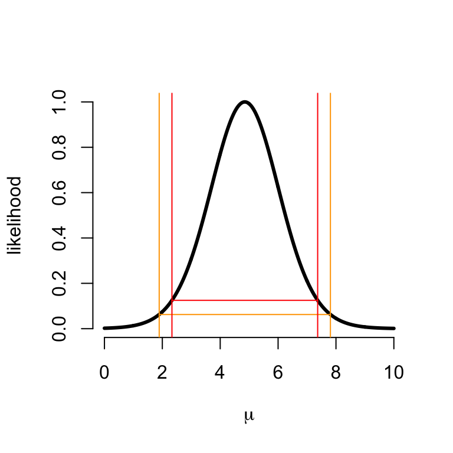

```r
## Erase past settings of number of plots in one window to default (=1)
par(mfrow = c(1,1))
## Vector of mu values we consider
muVals <- seq(0, 10, length = 1000)
## For each element in vector of mu values, compute corresponding
## profile likelihood
likeVals <- sapply(muVals, function(mu) sum((diff - mu)^2) ^ (-n/2))
## Normalize values
likeVals <- likeVals / max(likeVals)
plot(muVals, likeVals, type = "l", xlab = expression(mu),
     ylab = "likelihood", frame = FALSE, lwd = 3)
lines(range(muVals[likeVals>1/8]), c(1/8,1/8), col = "red")
lines(range(muVals[likeVals>1/16]), c(1/16,1/16), col = "orange", cex = 3)
abline(v = range(muVals[likeVals>1/8]), col = "red")
abline(v = range(muVals[likeVals>1/16]), col = "orange")
```

```r
## 1/8 interval
range(muVals[likeVals>1/8])
```

```
## [1] 2.332332 7.367367
```

```r
## MLE for the mean difference
muVals[which(likeVals == max(likeVals))]
```

```
## [1] 4.854855
```

### e. Create a profile likelihood for the variance of the difference in alcohol levels and interpret.

- We have seen above that in formula for $\hat{\sigma^2}(\mu)$ (maximum likelihood estimator of $\sigma^2$ for our model while treating $\mu$ fixed), the estimator is of a form: $\hat{\sigma^2}(\mu) = \frac { 1 } { n } \sum _ { i = 1 } ^ { n } \left( x _ { i } - \mu \right) ^ { 2 }$; in particular, it is a function of $\mu$.
- We will see that maximum likelihood estimator of $\mu$ for our model while treating $\sigma^2$ fixed turns out **not** to be a function of $\sigma^2$; in other words: true value $\sigma^2$ does not affect how maximum likelihood estimator of $\mu$ for our model looks like for data from this model (normal distribution).
- To obtain maximum likelihood estimator of $\mu$ for our model while treating $\sigma^2$ fixed, we perform the familiar procedure: compute log-likelihood, compute derivative of log-lokelihood with respect to $\mu$, set it to $0$ and solve for $\mu$.

Compute log-likelihood (copy-paste from above):

$$\begin{aligned}
\log L(\mu,\sigma^2\mid \boldsymbol{x}) = - \frac { n } { 2 } \ln ( 2 \pi ) - \frac { n } { 2 } \ln \left( \sigma ^ { 2 } \right) - \frac { 1 } { 2 \sigma ^ { 2 } } \sum _ { i = 1 } ^ { n } \left( x _ { i } - \mu \right) ^ { 2 }
\end{aligned}$$

Compute derivative of log-likelihood with respect to $\mu$, set to $0$ and solve for $\mu$:

$$\begin{aligned}
\frac{\partial}{\partial \mu}\log L(\mu,\sigma^2\mid \boldsymbol{x})
& = \frac{\partial}{\partial \mu} \left( - \frac { n } { 2 } \ln ( 2 \pi ) - \frac { n } { 2 } \ln \left( \sigma ^ { 2 } \right) - \frac { 1 } { 2 \sigma ^ { 2 } } \sum _ { i = 1 } ^ { n } \left( x _ { i } - \mu \right) ^ { 2 } \right) \\
& = \frac { 1 } { \sigma ^ { 2 } } \sum _ { i = 1 } ^ { n } \left( x _ { i } - \mu \right) \\
& = \frac { 1 } { \sigma ^ { 2 } } \left( \sum _ { i = 1 } ^ { n } x _ { i } \right) - \frac { 1 } { \sigma ^ { 2 } } n \mu \\
& \overset{set}{=} \; 0 \\
\Rightarrow & \hat{\mu}(\sigma^2) = \hat{\mu} = \frac { 1 } { n } \sum _ { i = 1 } ^ { n } x _ { i } = \overline{x}_n
\end{aligned}$$

- We see that formula for $\hat{\mu}(\sigma^2)$ is **not** a function of $\sigma^2$. Indeed, $\hat{\mu}(\sigma^2) = \hat{\mu} = \overline{x}_n$. Hence the profile likelihood for the variance is

$$\begin{aligned}
PL(\sigma^2\mid\boldsymbol{x}) & = L(\sigma^2, \mu(\sigma^2)\mid\boldsymbol{x}) \\
& =\frac{1}{(2\pi\sigma^2)^{n/2}}\exp\Big\{-\frac{\sum_i^{n}(x_i-\mu(\sigma^2))^2}{2\sigma^2}\Big\} \\
& =\frac{1}{(2\pi\sigma^2)^{n/2}}\exp\Big\{-\frac{\sum_i^{n}(x_i-\bar{x})^2}{2\sigma^2}\Big\}.
\end{aligned}$$

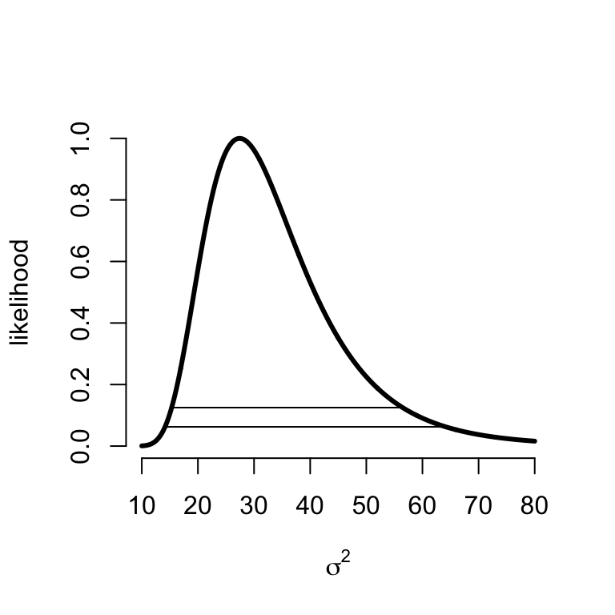

```r
sigmaVals <- seq(10, 80, length = 1000)
likeVals = 1/(sigmaVals^(n/2))*exp(-sum((diff-mean(diff))^2)/2/sigmaVals)
likeVals = likeVals/max(likeVals)
plot(sigmaVals, likeVals,
     type = "l",
     frame = F,
     xlab = expression(sigma^2),
     ylab = "likelihood", lwd = 3)
lines(range(sigmaVals[likeVals >= 1 / 8]), c(1 / 8, 1 / 8))
lines(range(sigmaVals[likeVals >= 1 / 16]), c(1 / 16, 1 / 16))
```

## HW4 Problem 17

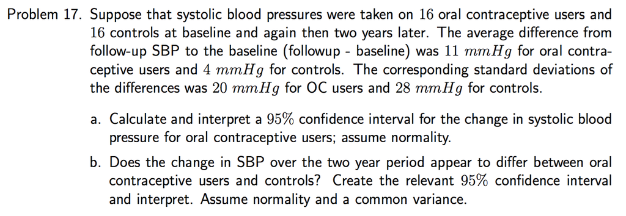

### a. Calculate and interpret a 95% confidence interval for the change in systolic blood pressure for oral contraceptive users; assume normality.

Because we assume normality, we can create a 95% confidence interval using the appropriate t-statistic as

$$11 \pm t_{0.975,15}\frac{20}{\sqrt{16}} = (0.34, 21.67)$$

That $0$ is not in the confidence interval implies a statsitcally significant increase in blood pressure among oral contraceptive users following a 2-year period of use. Plausable ranges for the true mean increase in blood pressure are values between 0.34 and 21.67.

```r
11 + c(-1,1)*qt(0.975, 15)*20/sqrt(16)
```

```
## [1]  0.3427523 21.6572477
```

### b. Does the change in SBP over the two year period appear to differ between oral contraceptive users and controls? Create the relevant 95% confidence interval and interpret. Assume normality and a common variance.

- Since we assume normality and common variance we can use a two sample t-test and the pooled variance estimator to estimate the difference in blood pressure comparing OC users vs controls.
- We use the following result ([source link](https://onlinecourses.science.psu.edu/stat414/node/201/); proof also to be found there):

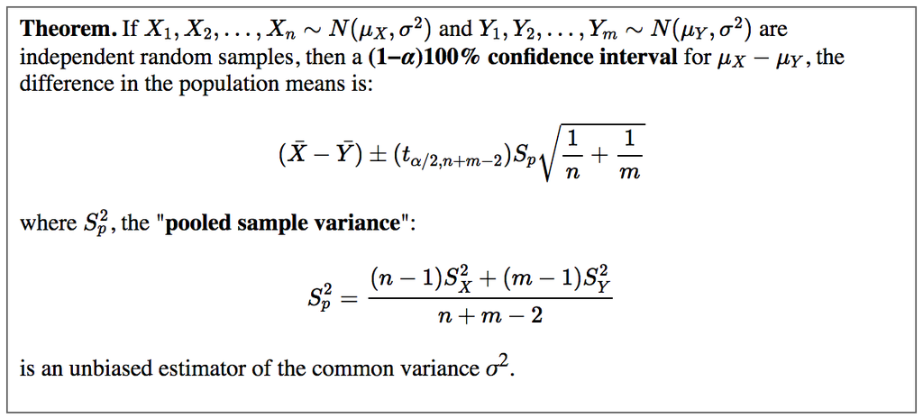

- Let $\bar{X}_{\text{OC}}, \bar{X}_{\text{control}}$ be the average difference in blood pressure for individuals on OC versus control, respectively.
- A $95$% confidence interval for the difference between the groups is

$$(\bar{X}_{\text{OC}} - \bar{X}_{\text{control}}) \pm t_{0.975,df=30}S_p\left(\frac{2}{16} \right)^{1/2} = (-10.57,24.57)$$

```r
n      <- 16
## average difference from follow-up to baseline in 2 groups
d_OC   <- 11;   d_c <- 4
## standard deviations in 2 groups
sd_OC  <- 20;  sd_c <- 28

## Pooled variance estimate
sd2_pool <- (sd_OC^2 + sd_c^2)*(n-1)/(2*n-2)
sd_pool  <- sqrt(sd2_pool)

## CI interval
(d_OC - d_c) + c(-1,1)*qt(0.975, df=2*n-2)*sd_pool*(2/n)^(1/2)
```

```
## [1] -10.56829  24.56829
```

- Conclusion: the $95$% confidence interval contains $0$ and thus we do not see a statistically significant difference in change in blood pressure comparing oral contraceptive users to controls.